# Incidents Responded to Across the City of Austin

### Dimension Reduction

A Principal Component Analysis (PCA) model is performed by selecting all of the columns that are numeric and removing the `Target.On.Time.Compliance` and `Month.Key` columns (these two columns are more used as definition variables where one column defines the target goal compliance while the other column defines the month/year of when the observations were recorded). Before the PCA could be done, though, the numeric variables were scaled by subtracting the mean from each variable and then dividing by the standard deviation.

```r
#PCA model
incidents_pca <- incidents1 %>%
  select(is.numeric, -Target.On.Time.Compliance, -Month.Key) %>%
  scale %>%
  prcomp
```

A scree plot was created to visualize the variance created by each component and to determine the number of principal components that would be used.

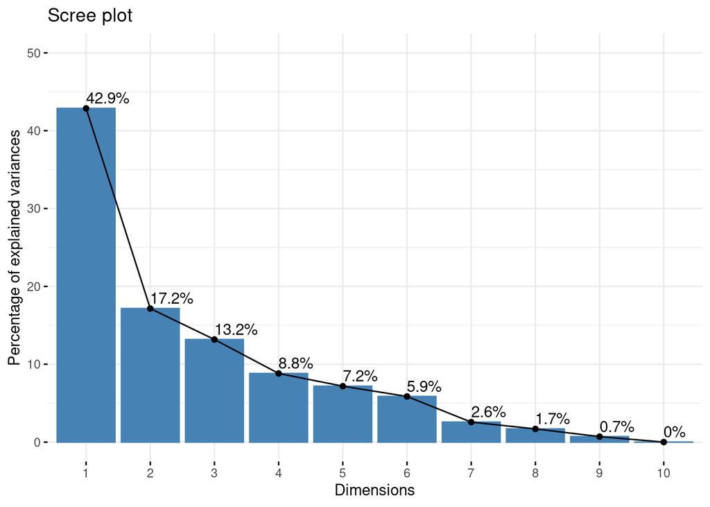

```r
# Visualize percentage of variance explained for each PC in a scree plot
fviz_eig(incidents_pca, addlabels = TRUE, ylim = c(0, 50))
```

The principal component values indicate the percent variance that those particular PCs account for regarding the data. Scoring high for the first two PCs means that the first two PCs account for most of the variance of the data and vice versa for scoring low (first two PCs don’t account for as much of the variance of the data to where more PCs have to be retained).

Afterwards, the observations were visualized using the first two PCs.

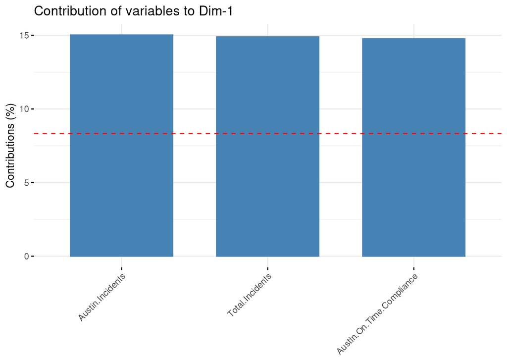

```r
# Top contributions of the variables to the PC as a percentage
fviz_contrib(incidents_pca, choice = "var", axes = 1, top = 3) # on PC1
```

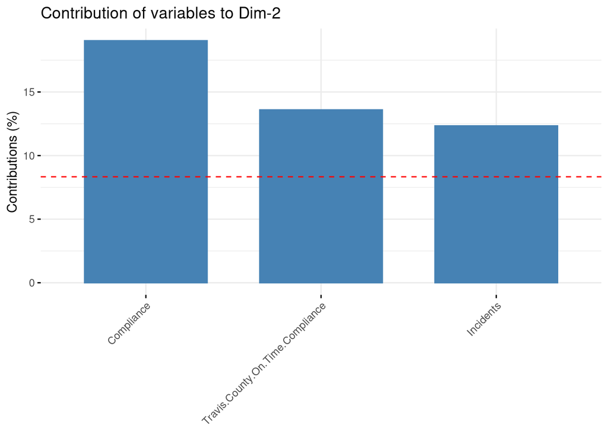

```r
fviz_contrib(incidents_pca, choice = "var", axes = 2, top = 3) # on PC2
```

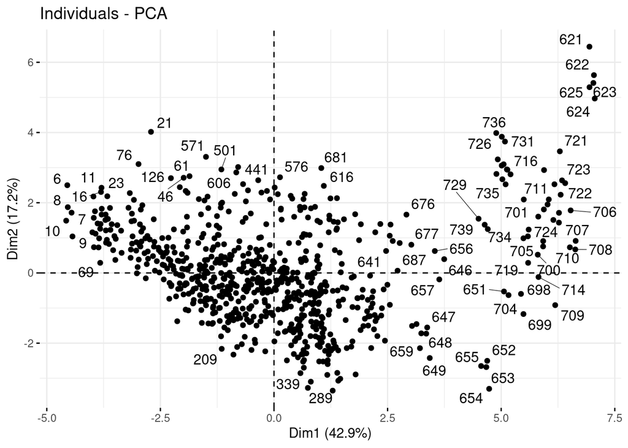

```r
# Visualize the individuals according to PC1 and PC2
fviz_pca_ind(incidents_pca, repel = TRUE)
```

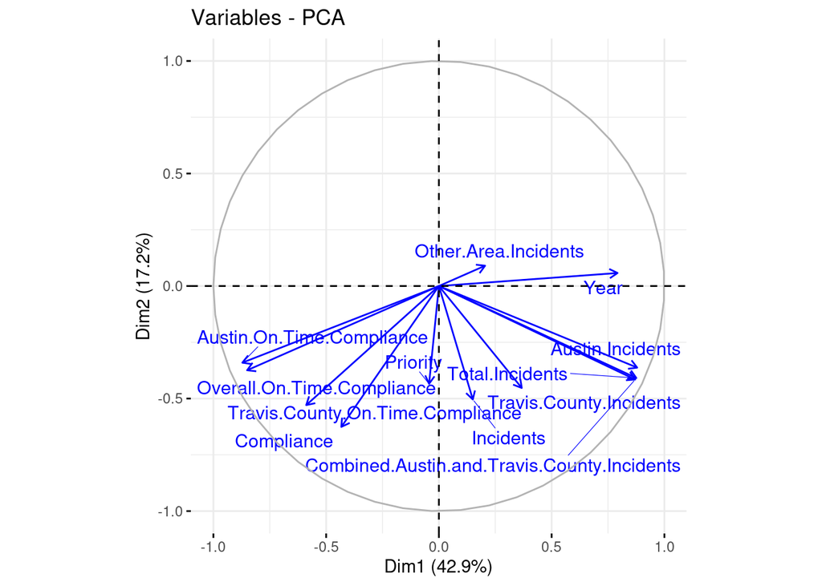

```r
# Visualize both variables and individuals in the same graph
fviz_pca_var(incidents_pca, col.var = "blue",
             repel = TRUE) # Avoid text overlapping of the variable names
```

Before interpreting the correlation circle, it must be established first that contributing negatively to a component means that there is a negative correlation between the principal component and the variable. On the other hand, contributing positively means that there is a positive correlation between a principal component and variable.

Looking at the correlation circle, the variables `Other.Area.Incidents`, `Austin.Incidents`, `Total.Incidents`, `Combined.Austin.and.Travis.County.Incidents`, `Travis.County.Incidents`, and `Incidents` contribute to the first component positively while `Priority`, `Compliance`, `Travis.On.Time.Compliance`, `Overall.On.Time.Compliance`, and `Austin.On.Time.Compliance` contribute negatively to the first component.

### Clustering

As the kNN model was used to construct the relationship between the variables, the k-means clustering method was used to predict whether or not compliance was met. First the optimal number of clusters was determined.

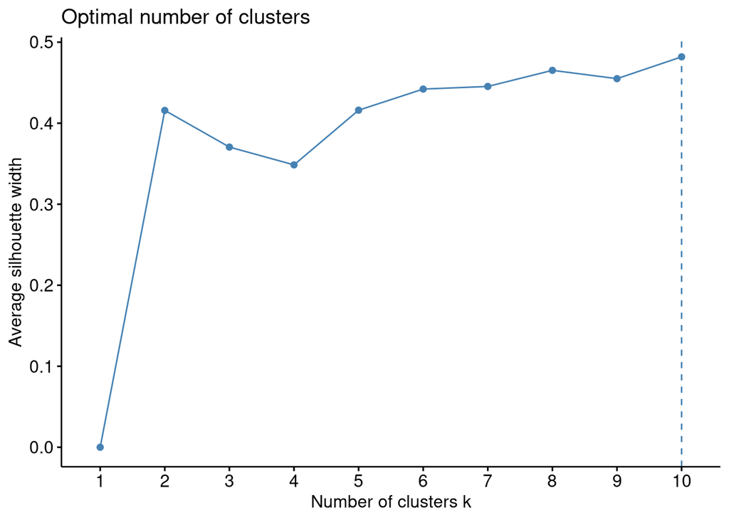

```r
#scale data
incidents_scaled <- incidents1 %>%
  select(Compliance, Priority, Incidents, Year) %>%
  scale

# Maximize the silhouette while keeping a small number of clusters
fviz_nbclust(incidents_scaled, kmeans, method = "silhouette")
```

As a result, 10 clusters was determined to be optimal for creating a cluster graph of the data.

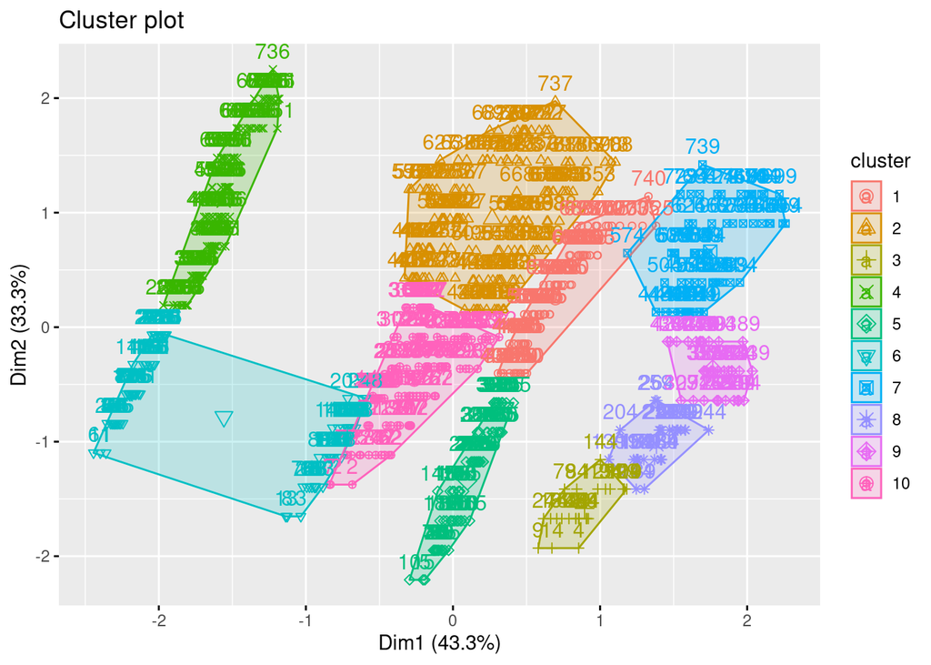

```r
# Use the function kmeans() to find clusters
kmeans_results <- incidents1 %>%
  select(Priority, Incidents, Year) %>%
  scale %>%
  kmeans(centers = 10) # change to 6 centers

# Visualize the clusters
fviz_cluster(kmeans_results, data = incidents1 %>% select(Priority, Incidents, Year))
```

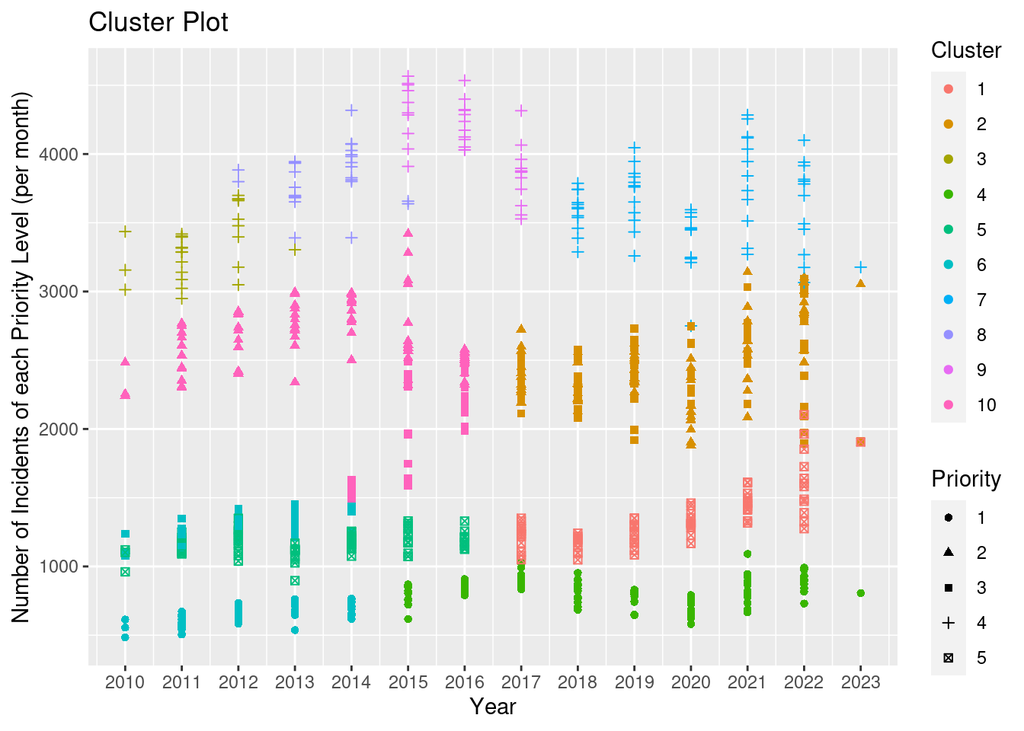

```r
# Let's visualize the clusters
incidents1 %>%
  mutate(cluster = as.factor(kmeans_results$cluster)) %>%
  ggplot(aes(x = Year, y = Incidents, color = cluster, shape = as.character(Priority))) +
  geom_point()  +
  scale_x_continuous(breaks = seq(2010,2023,1)) +
  labs(title = "Cluster Plot",
       x = "Year",
       y = "Number of Incidents of each Priority Level (per month)",
       color = "Cluster",
       shape = "Priority")
```

Based on the cluster plot with the top 2 PCs of just the three variables, there seems to be a relatively clear separation between the ten different clusters. Nonetheless, it seems difficult to apply that cluster plot with the data, thus ggplot() was used to further examine the clusters and how they relate to the variables being examined.

After fitting the variables using ggplot() for a clearer interpretation, it seems to be that the clusters divide the priority levels, for the most part, into smaller groups from their original priority level clusters. Take Priority Level 4 as an example where it is divided between 4 different clusters, meaning that the priority levels are spread out far enough to where there are multiple means within a priority level. There also seems to be some overlap between priority levels and clusters, but overall, the clusters do a pretty good job at separating the clusters into their original priority levels.

Across the board, the ggplot() demonstrates how there are constant fluctuations between number of incidents for each cluster over time, but it also demonstrates that the more severe the priority level, the lower the amount of incidents that occur (priority level 1 is near the lower half of the y-axis and priority level 4 is near the upper half of the y-axis).

### Discussion

The combination of the three variables (Priority level of the patient, the number of incidents responded to for each priority level, and year) seemed to predict well of whether or not compliance goal was met according to the kNN model that was done. The AUC value of the kNN model was 0.9649377, indicating that the three variables were good predictors of the outcome variable. However, when cross-validation was performed, it demonstrated that the kNN values had an accuracy of around 0.9/0.91 meaning that the kNN model isn’t as accurate as I would like since there may have been some slight overfitting that occurred. However, it would be inconclusive to determine that there was overfitting that happened since the accuracy is still quite high. Looking at the correlation circle of the PC models, it seems that all three of these variables had some strength in terms of accounting for the variation in the data. Meanwhile, the cluster plots indicate that there are groups within the data that differ slightly from their original grouping, but each of the groups or clusters seem to have similar relationships between priority level incidents and total incidents. This means that these variables may have the same effect within the clusters across the board on whether the compliance requirement set was met.

The process for this particular project was a lot more intensive compared to the previous project. In the previous project, we were continually building on the functions we already knew, but for this project, we had only learned some of these concepts for one class day before moving on to the next concept. As a result, the biggest challenge in this report was relearning everything and trying to understand what the purpose behind each function was. I found myself spending more time on trying to interpret the models and visualizations I created rather than creating the visualizations themselves. As a result, I want to say that I have gained more insight in predicting variables and finding the predictors of certain variables, but I also believe that doing a personal project over the summer to truly hammer in these ideas would be beneficial.

Acknowledgments: The City of Austin’s Government for providing the datasets I used for this research project and Dr. Layla Guyot for answering questions that I had while conducting this project.

Sources:  
Incidents Data: https://data.austintexas.gov/Public-Safety/EMS-Incidents-by-Month/gjtj-jt2d/